# Manual - `xadmix`

### Grouped Stacked Barplots & Customized Appearance

More information can be gained by looking at the subsets generated above:

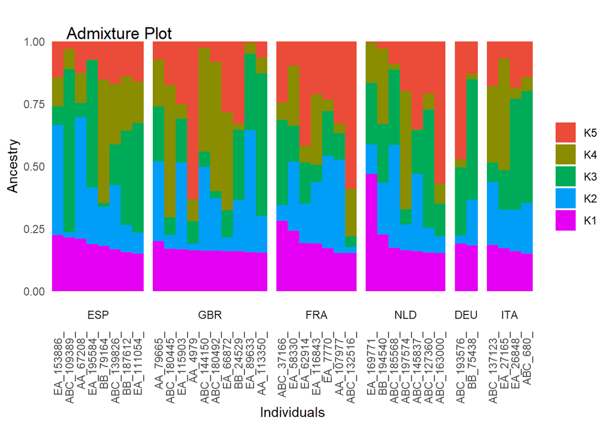

```r
# grouping data by column "country",
# and sorting each group by ancestry column "K1"
admix_barplot(subset1,
   K = 4:ncol(xadmixture),
   grouping = "country",
   sortkey = "K1"
)
```

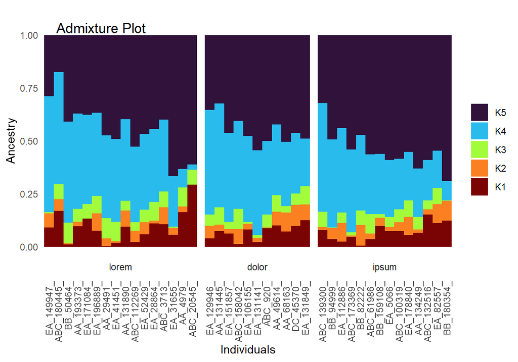

```r
# changing color palette to "turbo" from package 'viridis',
admix_barplot(subset2,
   K = 4:ncol(xadmixture),
   palette = "turbo",
   grouping = "species",
   sortkey = "K4"
)
```

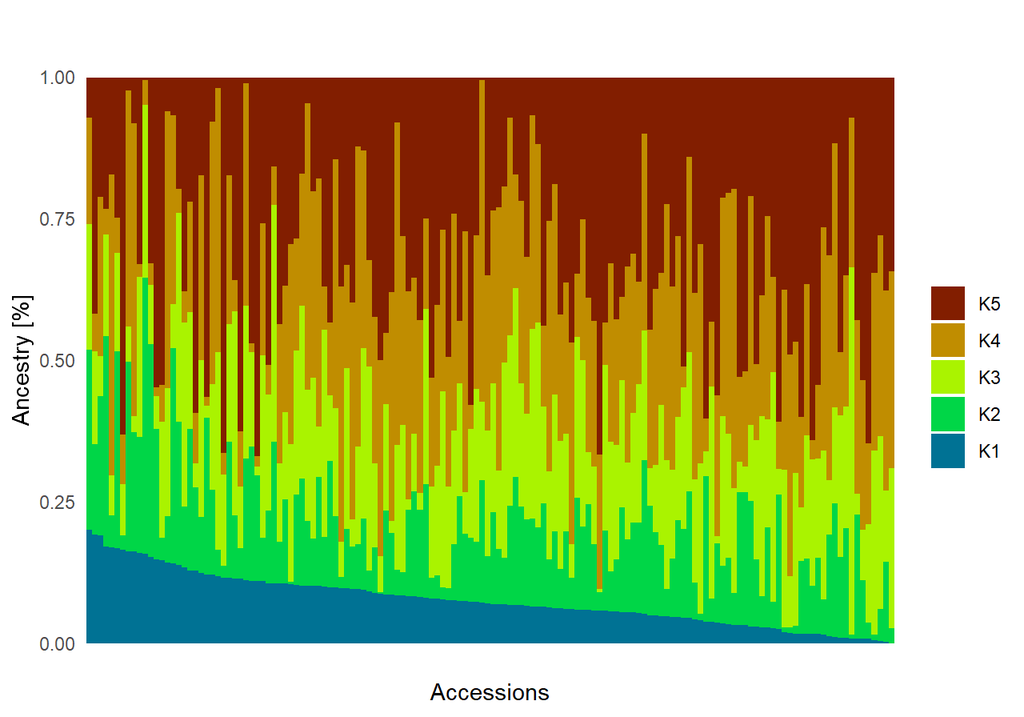

```r
# removing title and changing axis labels text
admix_barplot(subset3,
   K = 4:ncol(xadmixture),
   main = "",
   xlab = "Accessions",
   ylab = "Ancestry [%]",
   palette = "alternating",
   sortkey = "K1",
   names = FALSE
)
```

### Noclip Feature

Sometimes the group labels can get cut off. When there are not enough observations in the group, the width of the grouped bars can be smaller than the width of the group label. `ggplot2` does not yet offer a flag to avoid this problem. In `xadmix`, however, there is an option to remove clipping altogether:

```r
# directly output grouped plot with clipping removed from elements
# (useful if there are groups with a low number of observations)
subset5 <- admix_subset(xadmixture,
                        anc = c("K3", "K4"),
                        pct = c(0.3, 0.2),
                        quiet = TRUE)
```

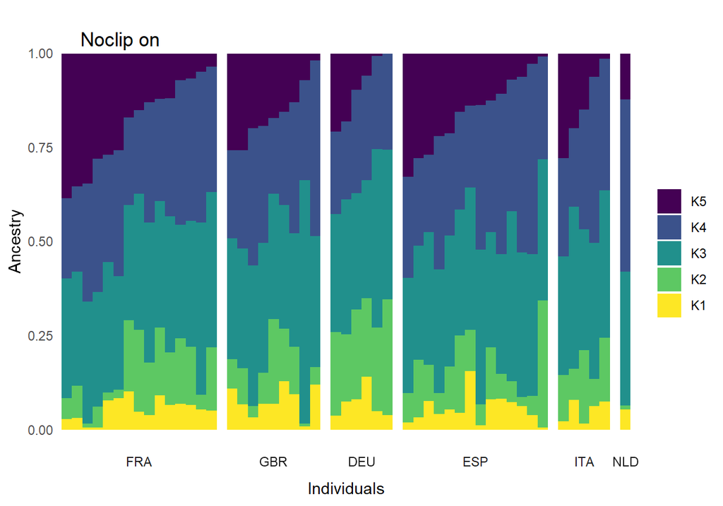

```r
# noclip set to "TRUE"
admix_barplot(subset5,
            K = 4:ncol(xadmixture),
            sortkey = "K5",
            grouping = "country",
            palette = "viridis",
            names = FALSE,
            main = "Noclip on",
            noclip = TRUE)
```

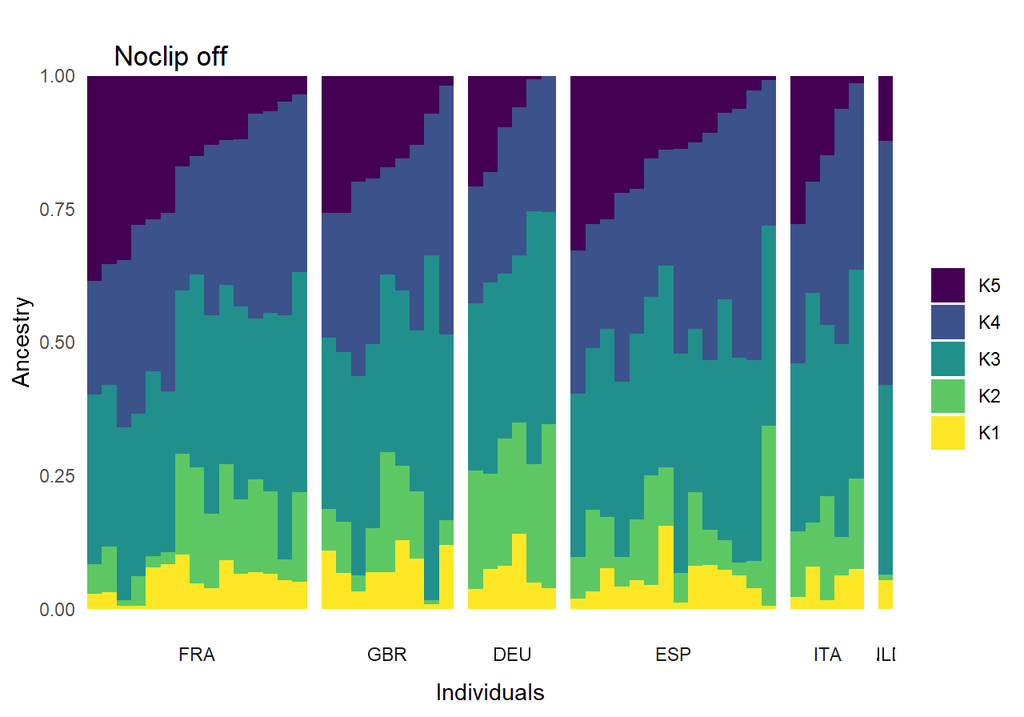

```r
# noclip set to "FALSE"
admix_barplot(subset5,
            K = 4:ncol(xadmixture),
            sortkey = "K5",
            grouping = "country",
            palette = "viridis",
            names = FALSE,
            main = "Noclip off",
            noclip = FALSE)
```

♦